# Data Coding Challenge: Implications of a Movie Loyalty Membership Program

Chuan Hong

3/20/2017

## 1. Introduction

In recent years, loyalty membership programs are popular and ubiquitous marketing instruments. Understanding the efficacy of a loyalty program is important for further marketing campaign and promotion. The project shown here is a data analysis based on a two-years (2012-2014) data of movie memberships, consist of 9995 loyalty customers and 10005 non-loyalty customers. The distribution of gender, location, and age are similar between these two groups.

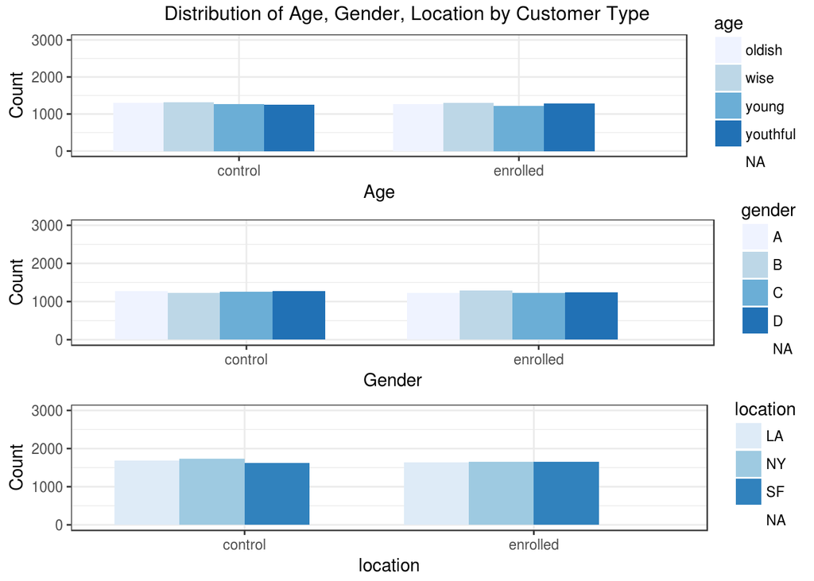

## 2. Time Interval between Purchases

One primary aim of loyalty programs is to increase customer retention. It means that every company wants their customer to come back to buy more products after they make the first purchase. In this project, I caltulated time interverval between purchases and purchase frequences to investigate the loyalty customers retention status.

The graphs below show that the mean time to first purchase of loyalty customers (64 days) is significnalty less than that of non-loyealty customer (75 days) (Mann-Whitney-Wilcoxon test, p<0.05).

```
## $control
##    Min. 1st Qu.  Median    Mean 3rd Qu.    Max.
##    0.00   12.00   40.00   74.91  105.00  666.00
##
## $enrolled
##    Min. 1st Qu.  Median    Mean 3rd Qu.    Max.
##    0.00    9.00   34.00   64.44   89.00  625.00
```

```
##
##  Wilcoxon rank sum test with continuity correction
##
## data:  time_to_first_purchase by loyalty
## W = 19313000, p-value = 1.069e-10
## alternative hypothesis: true location shift is not equal to 0
```

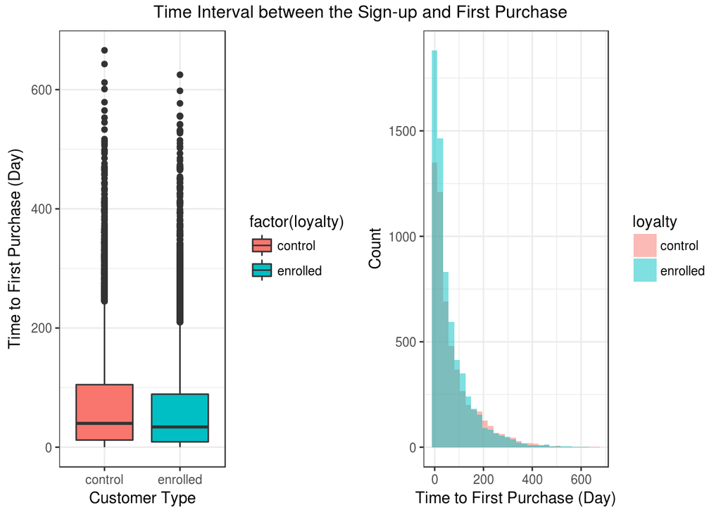

Similarly, the time between purchases among loyalty customers (67 days) is significantly than that of non-loyalty customers (77 days). It implies that loyal program potentially influences the purchase bahaviors (Mann-Whitney-Wilcoxon test, p<0.05).

```
## $control
##    Min. 1st Qu.  Median    Mean 3rd Qu.    Max.
##    0.50   23.50   64.33   76.88  109.50  359.50
##
## $enrolled
##    Min. 1st Qu.  Median    Mean 3rd Qu.    Max.
##    1.00   21.32   54.42   67.33   93.60  355.00
```

```
##
##  Wilcoxon rank sum test with continuity correction
##
## data:  time_between_purchases by loyalty
## W = 19742000, p-value < 2.2e-16
## alternative hypothesis: true location shift is not equal to 0
```

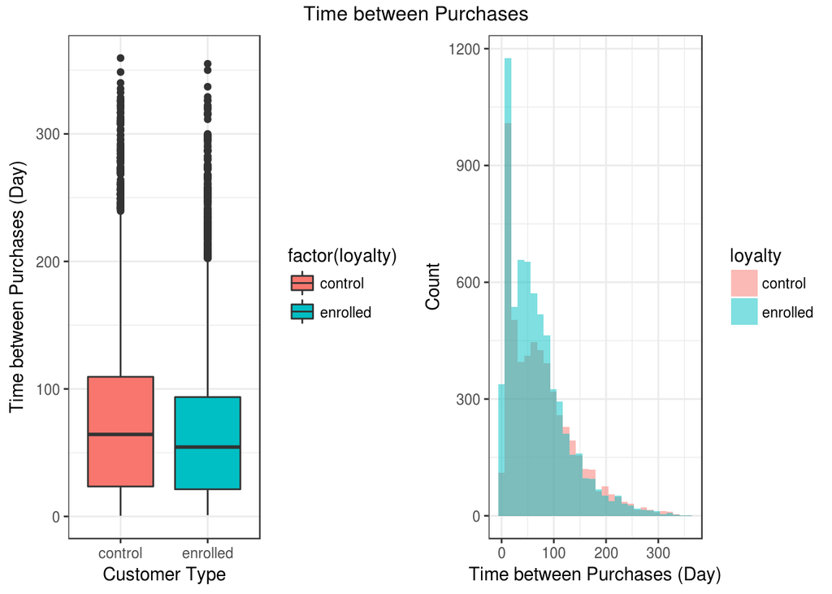

## 3. Purchase Frequency

The purchase frequency here is defined as the number of times that a customer has made a purchase in this program. The distribution of the whole number of purchases shows that loyalty customers (mean:9, range:0-216) purchased more frequently than non-loyalty customers (mean=6, range:0-136) (Mann-Whitney-Wilcoxon test, p<0.05).

```
## $control
##    Min. 1st Qu.  Median    Mean 3rd Qu.    Max.
##   0.000   0.000   2.000   6.336   5.000 136.000
##
## $enrolled
##    Min. 1st Qu.  Median    Mean 3rd Qu.    Max.
##   0.000   1.000   3.000   9.444   8.000 216.000
```

```
##
##  Wilcoxon rank sum test with continuity correction
##
## data:  number_of_purchases by loyalty
## W = 42491000, p-value < 2.2e-16
## alternative hypothesis: true location shift is not equal to 0
```

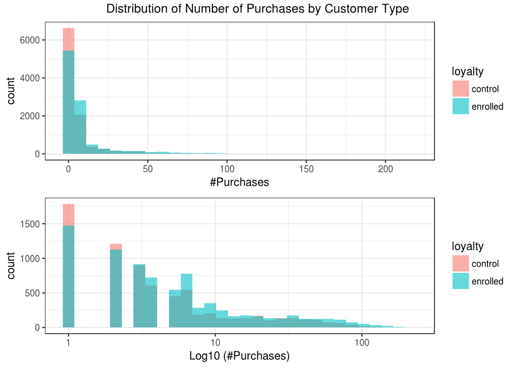

## 4. Purchase Value

Then, let’s take a look if loyalty program promoted the purchase value during the two years. The real payment of purchase among loyalty customers (mean:28660, range:0-1424000) are significalty higher that of other customers (mean:17460, range:0-1074000)(Mann-Whitney-Wilcoxon test, p<0.05).

```
## $control
##    Min. 1st Qu.  Median    Mean 3rd Qu.    Max.
##       0       0    3255   17460   12510 1074000
##
## $enrolled
##    Min. 1st Qu.  Median    Mean 3rd Qu.    Max.
##       0    1118    5686   28660   20330 1424000
```

```
##
##  Wilcoxon rank sum test with continuity correction
##
## data:  customers$value_of_purchases - customers$total_points_redeemed/10 by loyalty
## W = 42704000, p-value < 2.2e-16
## alternative hypothesis: true location shift is not equal to 0
```

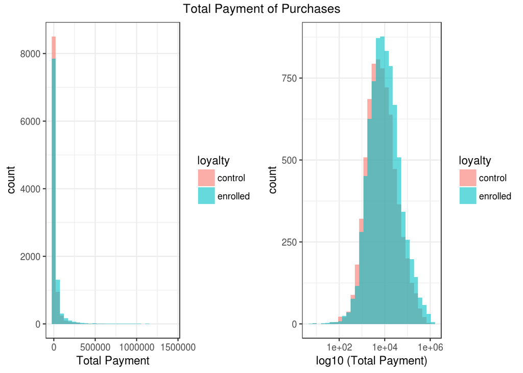

Interestingly, compared to non-loyalty custromers (2612 cents/order), the average order value is slightly higher among loyalty customers (2748 cents/order). It seems like that loyalty program promotes customes to purchaser more expensive products.

```
## $control
##    Min. 1st Qu.  Median    Mean 3rd Qu.    Max.
##       0    1242    2098    2612    3405   13240
##
## $enrolled
##    Min. 1st Qu.  Median    Mean 3rd Qu.    Max.
##    12.5  1297.0  2172.0  2748.0  3605.0 14550.0
```

```
##
##  Wilcoxon rank sum test with continuity correction
##
## data:  average_order_value by loyalty
## W = 17440000, p-value = 0.0007782
## alternative hypothesis: true location shift is not equal to 0
```

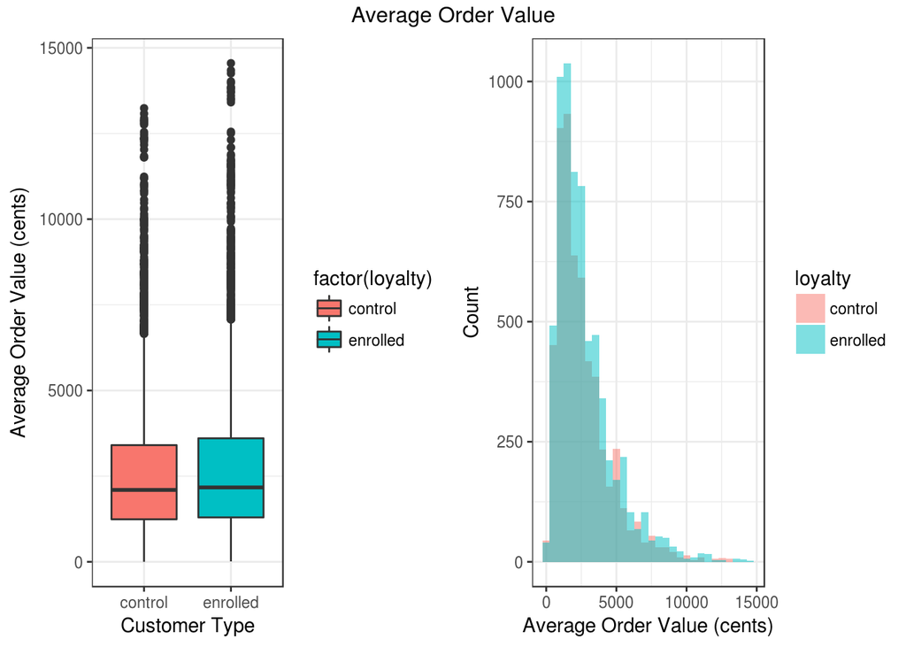

## 5. Conclusion

Summarily, this loyalty program effectively influences custermer’s purchase decision:

1. Loyalty customers are more avtively and frequently to buy products;
2. Loyalty customers contribute more profit than non-loyal custermers;
3. Loyalty customers are more likely to come back to buy more products.